# compile-regional-data

### 2.2.7 East Vancouver Island & Mainland Inlets

In the 2025 State of Salmon report, we have split the former “Vancouver Island & Mainland Inlets” region into two: East Vancouver Island & Mainland Inlets and West Vancouver Island. This split was made to better reflect the different ecology and habitats of salmon between the regions that may lead to different status and trends.

#### Chinook

PSC’s Chinook Technical Committee (CTC) reports escapement (spawner abundance) and run size (total abundance) for three indicator stocks in the Strait of Georgia: Nanaimo, Cowichan, and Phillips (Chinook Technical Committee 2025). We report spawner abundance and total abundance as the sum of `Esc` and `t.run`, respectively, across these three indicator stocks as reported in Appendix Table B4 available from the [PSC’s Chinook Technical Committee (CTC) data sets](https://www.psc.org/publications/technical-reports/technical-committee-reports/chinook/ctc-data-sets/).

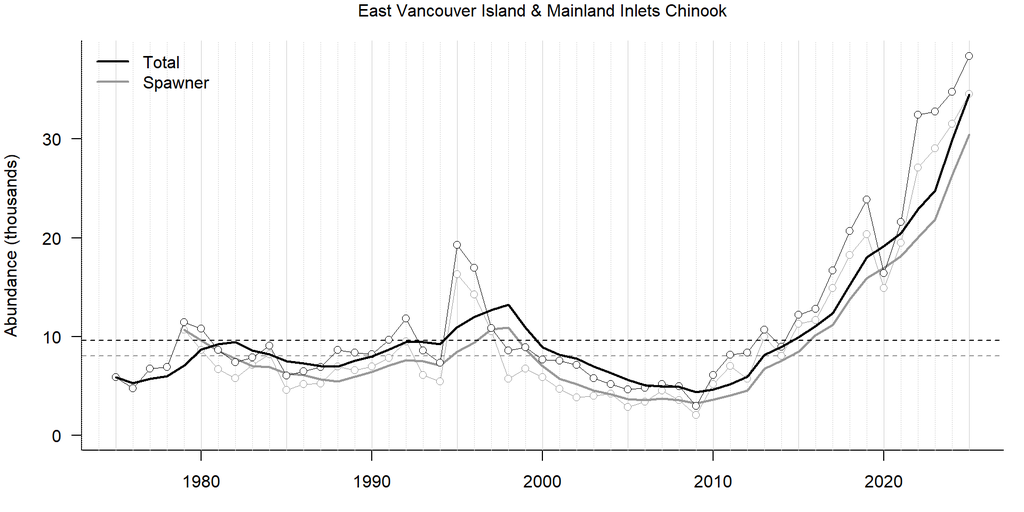

**Above:** Spawner abundance (grey) and total abundance (black) of East Vancouver Island & Mainland Inlets chinook salmon. For both, the raw data is shown by points and the smoothed metric by solid lines. Dashed horizonal lines represent the long-term average for each.

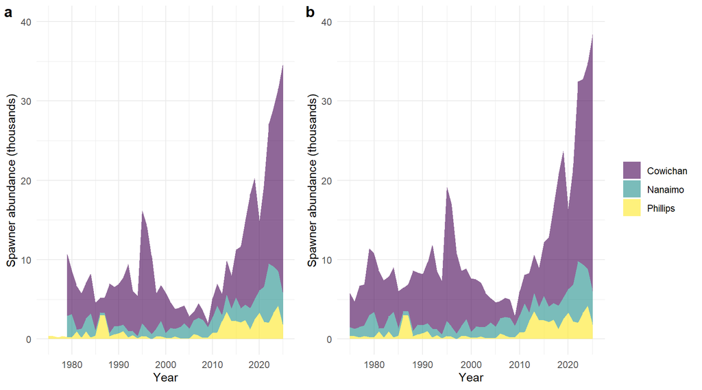

**Above:** (a) Chinook salmon spawner abundance and (b) total abundance showing the contributions of the Cowichan, Nanaimo, and Philips indicator stocks.

```r
## Load data --
# (1) CTC data
evimi_ctc <- readxl::read_xlsx(here("data/TCCHINOOK-2026-Appendix-B-Escapement-Detailed.xlsx"), sheet = "B4", range = "A5:G55", col_types = "numeric", col_names = c("Year", "Nanaimo_esc", "Nanaimo_trun", "Cowichan_esc", "Cowichan_trun", "Phillips_esc", "Phillips_trun")) # Southern BC

evimi_ctc_summed <- evimi_ctc %>%
    group_by(Year) %>%
    summarise(esc_sum = sum(Nanaimo_esc, Cowichan_esc, Phillips_esc),
                        trun_sum = sum(Nanaimo_trun, Cowichan_trun, Phillips_trun))

# Put in SPS format
evimick_sps <- data.frame(
    region = rep("East Vancouver Island & Mainland Inlets", dim(evimi_ctc_summed)[1]),
    species = rep("Chinook", dim(evimi_ctc_summed)[1]),
    year = evimi_ctc_summed$Year,
    spawners = evimi_ctc_summed$esc_sum,
    smoothedSpawners = NA,
    runsize = evimi_ctc_summed$trun_sum,
    smoothedRunsize = NA,
    source_id = rep(ctc_id, dim(evimi_ctc_summed)[1])
)

# Smoothing
evimick_sps$smoothedSpawners <- genSmooth(
    abund = evimick_sps$spawners,
    years = evimick_sps$year,
    genLength = genLength$gen_length[genLength$region == "East Vancouver Island & Mainland Inlets" & genLength$species == "Chinook"]
)

evimick_sps$smoothedRunsize <- genSmooth(
    abund = evimick_sps$runsize,
    years = evimick_sps$year,
    genLength = genLength$gen_length[genLength$region == "East Vancouver Island & Mainland Inlets" & genLength$species == "Chinook"]
)

# Add to master sps dataframe
sps_data <- rbind(sps_data, evimick_sps)

#Generate standard figures
plot_abund(evimick_sps)
```